# Chapter 15

6/15/2015

## Overview

In previous chapters, we saw

- How to describe to describe random phenomena with random variables
- How to describe the behavior of random variables with probability distributions
- Several named probability distributions
- How to decribe distributions with expected values (means) and standard deviations
- How to use these distributions to find probabilities of events occuring

## What now?

Say that the heights of men (in feet) are well-described by the following model:

\[X \sim N(\mu = 5.75,\; \sigma = 0.25)\]

How unusual would it be to randomly pick someone over 6 ft. tall?

- From StatCrunch, \(P(X \ge 6) = 0.159\)
- It's not all that rare, about 16% of men are above 6' tall

But what if we had more than one person?

- We could get a **sample** of men
- **Statistics** describe the sample

## Samples

Populations:

- Are groups that we are interested in studying (e.g., men)
- We describe characteristics of the population with variables (e.g., heights)
- If we draw an individual at random, we describe the probability of selecting particular values of the variable with the variable's **probability distribution**
- We often call the distribution of the individuals the **parent distribution**

Samples:

- Are **individual observations** drawn from a larger population
- The variables for each individual all have the same distribution

## The Sampling Distribution

Statistics are numeric descriptions of a sample, like the:

- Sample mean, \(\bar{x}\)
- Sample standard deviation, \(s\)
- Median
- Other quantiles (the min, quartiles, and max)

The **sampling distribution** of a statistic:

- Is the probability distribution of that statistic
- We can use them to gain insight into unknown parameters

## Sampling Variablity

Recall from chapter 10:

- If we take multiple samples and calculate statistics, they will vary slightly
- We call this variability the **sampling variability** or **sampling error**

How do we deal with sampling error?

- The **sampling distribution** describes the probability that the statistic takes different values
- The sampling error is the **standard deviation** of this distribution

## Sampling Distribution Example

As an illustration, we will drawn 10,000 samples of size \(n = 100\) from various distributions and look at the distribution of the:

- Min
- Median
- Max
- IQR
- Mean
- Standard Deviation

## The Parent Distribution: Uniform

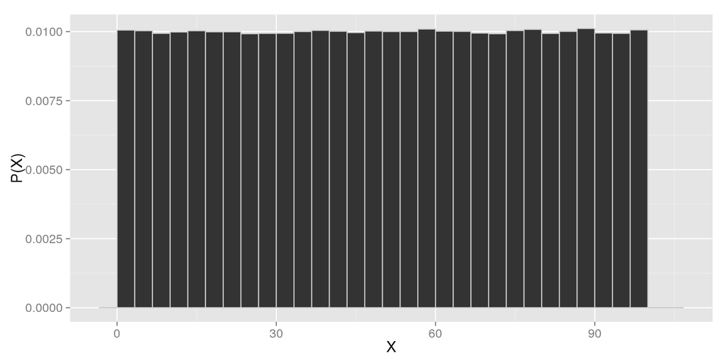

## Sampling Distributions

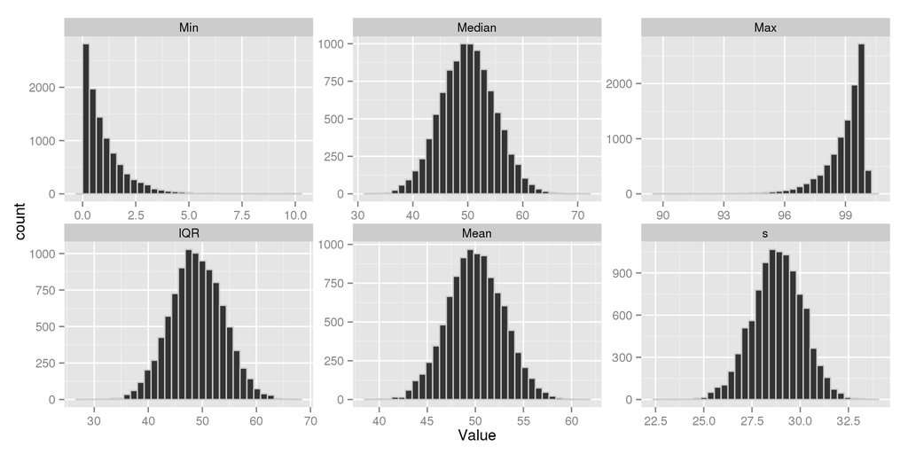

## The Parent Distribution: Right-Skewed

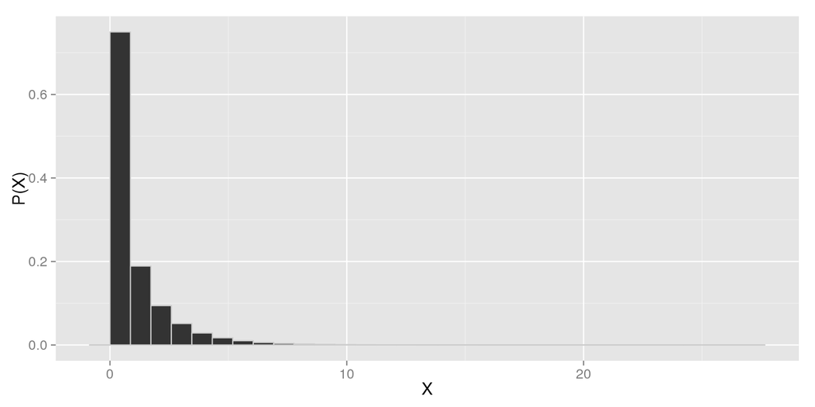

## Sampling Distributions

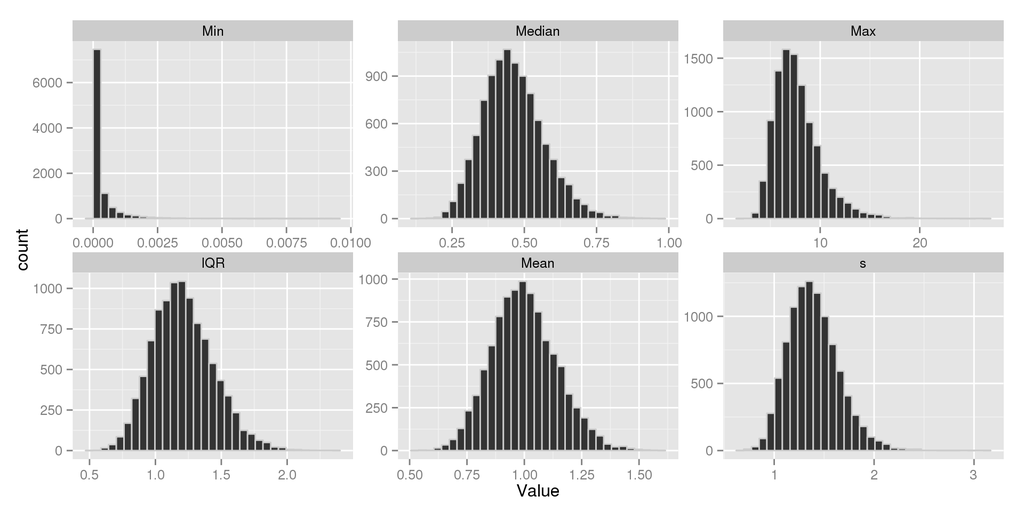

## The Parent Distribution: Bernoulli

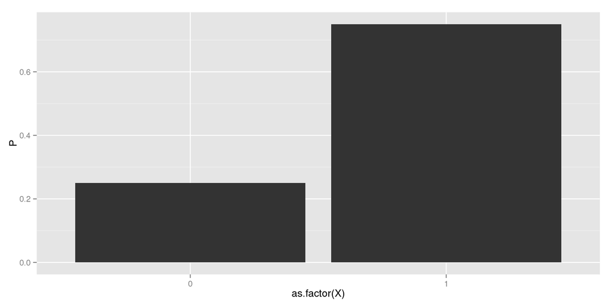

## Sampling Distributions

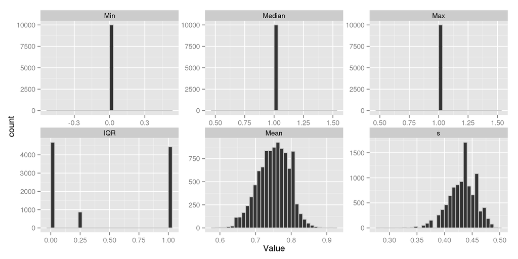

## The Parent Distribution

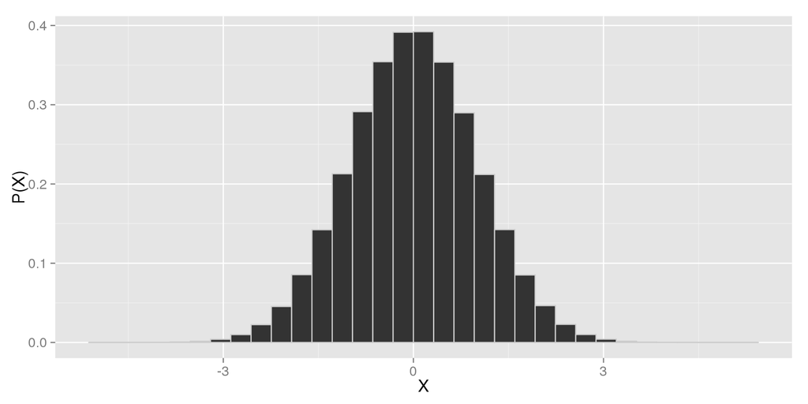

## Sampling Distributions

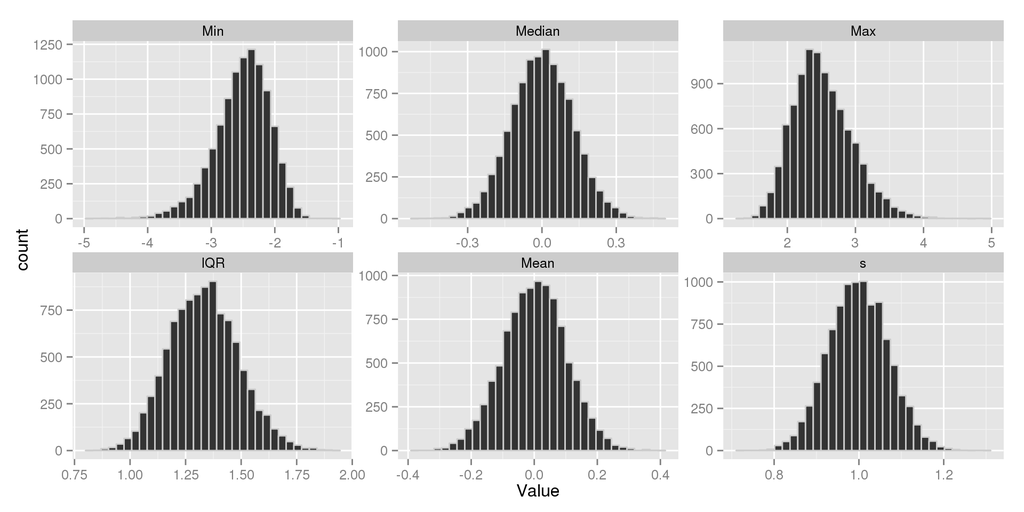

## What did we see?

As we changed the parent distribution:

- The distribution of **most** of the statistics changed

What didn't change?

- The distribution of the mean was always (nearly) normal
- This behavior is called the **central limit theorem**

## The Central Limit Theorem

The Central Limit Theorem (CLT) is essential to statistical methods. The CLT says that, for any random variable with a mean and standard deviation:

\[X \sim ?(\mu, \sigma)\]

If we repeatedly draw samples from this distribution and calculate their means, the sample means will follow a normal distribution:

\[\overline{X} \sim N\left(\mu, \frac{\sigma}{\sqrt{n}}\right)\]

As we increase \(n\):

- The distribution of \(\overline{X}\) gets closer to normal
- The standard deviation decreases

## CLT Example: Rolling Dice

To see the CLT in action, consider sets of dice 10,000 times:

If we roll 1 die:

- We can get 1, 2, 3, 4, 5, or 6 with equal probability

What if we rolled more than one each time, and average the faces?

- The **mean** should be around \(\mu = 3.5\)
- As we increase the number of die, the CLT says it should be more and more rare for \(\overline{X}\) to be far away from \(\mu\)

## Rolling 1 die

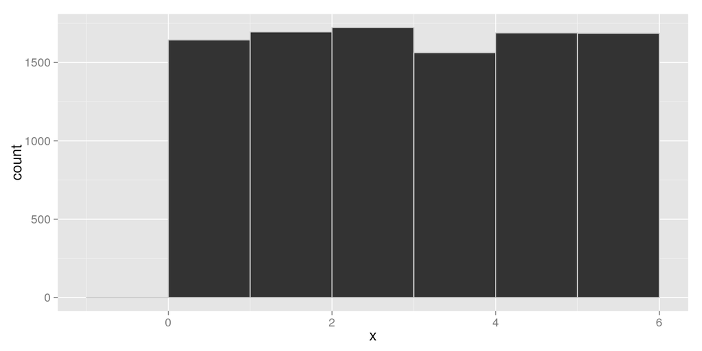